# Project Python Foundations: FoodHub Data Analysis

### **Question 7**: Which are the top 5 restaurants in terms of the number of orders received? [1 mark]

```python
#Counts the number of values per restaurant in descending order - provides top 5 restuarants using head(5) function
df['restaurant_name'].value_counts().head(5)
```

```
Shake Shack                  219
The Meatball Shop            132
Blue Ribbon Sushi            119
Blue Ribbon Fried Chicken     96
Parm                          68
Name: restaurant_name, dtype: int64
```

#### Observations: Shake Shack, The Meatball Shop, Blue Ribbon Sushi, Blue Ribbon Fried Chicken, and Parm are the top 5 restuarants in terms of number of orders received.

### **Question 8**: Which is the most popular cuisine on weekends? [1 mark]

```python
#groups the data by 'day_of_the_week' and 'cusine_type' and counts the values per group - separates 'weekday' from 'weekend'
df.groupby('day_of_the_week')['cuisine_type'].value_counts()
```

```
day_of_the_week  cuisine_type
Weekday          American          169
                 Japanese          135
                 Italian            91
                 Chinese            52
                 Indian             24
                 Mexican            24
                 Middle Eastern     17
                 Mediterranean      14
                 Southern            6
                 French              5
                 Thai                4
                 Vietnamese          3
                 Korean              2
                 Spanish             1
Weekend          American          415
                 Japanese          335
                 Italian           207
                 Chinese           163
                 Mexican            53
                 Indian             49
                 Mediterranean      32
                 Middle Eastern     32
                 Thai               15
                 French             13
                 Korean             11
                 Southern           11
                 Spanish            11
                 Vietnamese          4
Name: cuisine_type, dtype: int64
```

#### Observations: American is the most popular cuisine on the weekends.

### **Question 9**: What percentage of the orders cost more than 20 dollars? [2 marks]

```python
Cost20 = df[df['cost_of_the_order']>20] #creates a new dataframe showing orders that cost more than 20 dollars
Percentage = (Cost20.shape[0]/df.shape[0])*100 #calculates the percentage - based off the shape of the new dataframe divided by the shape of the original data frame multiplied by 100
Percentage
```

```
29.24130663856691
```

#### Observations: 29.2% of the orders cost more than 20 dollars.

### **Question 10**: What is the mean order delivery time? [1 mark]

```python
#calculates the mean for the values under the 'delivery_time' column
df['delivery_time'].mean()
```

```
24.161749209694417
```

#### Observations: The mean order delivery time is 24 minutes, approximately.

### **Question 11:** The company has decided to give 20% discount vouchers to the top 3 most frequent customers. Find the IDs of these customers and the number of orders they placed. [1 mark]

```python
#Counts the number of values per 'customer_id' in descending order - provides top 3 most frequent customers
df['customer_id'].value_counts().head(3)
```

```
52832    13
47440    10
83287     9
Name: customer_id, dtype: int64
```

#### Observations: Customer ID 52832 - (Number of orders - 13), 47440 - (Number of orders - 10), and 83287 - (Number of orders - 9) are the top 3 most frequent customers.

### **Question 12**: Perform a multivariate analysis to explore relationships between the important variables in the dataset. (It is a good idea to explore relations between numerical variables as well as relations between numerical and categorical variables) [10 marks]

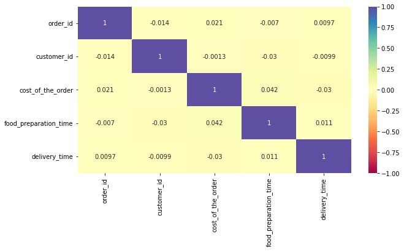

```python
plt.figure(figsize=(10,5)) #creates the size of the graph
sns.heatmap(df.corr(),annot=True,cmap="Spectral",vmin=-1,vmax=1) #creates a heatmap that will show the correlation between all numerical variables
plt.show()
```

### Observations: According to the Heatmap, all numerical variables show close to 0 correlation. Therefore valid insights cannot be produced from this visualization.

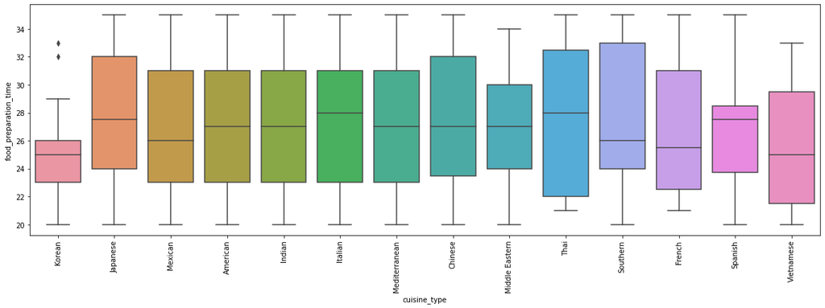

```python
#Food preparation time and cuisine type - Relationship
plt.figure(figsize=(20,6)) #creates the size of the graph
sns.boxplot(data=df,x='cuisine_type', y="food_preparation_time") #creates a boxplot, analyzing the variables 'cuisine_type' and 'food_preparation_time"
plt.xticks(rotation = 90)
plt.show()
```

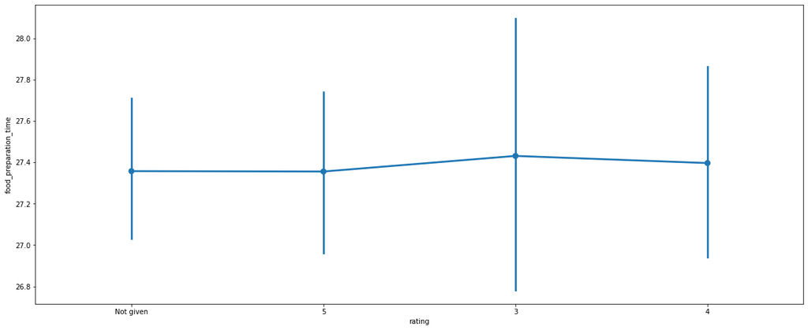

```python
#Food Preparation Time vs Rating
plt.figure(figsize=(20,8)) #creates the size of the graph
sns.pointplot(data=df,x='rating', y="food_preparation_time")  #creates a pointplot, analyzing the two variables 'rating' and 'food_preparation_time'
plt.show() #displays the graph
```

## Observations: According to the graph, rating of 3 has the highest food preparation time as compared to rating of 4 and 5. Rating of 5 is given to the lowest food preparation time. 'Not given" is irrelavent. However, the difference in food preparation time between each rating is very slight so the insights provided from this data may not help the business.

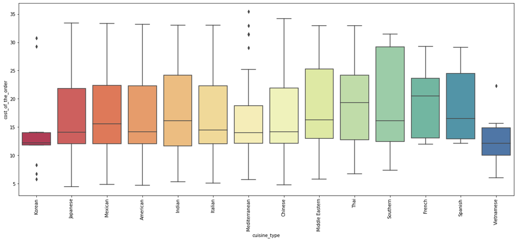

```python
#Relationship between Cuisine Type and Cost of the order
plt.figure(figsize=(20,8))
sns.boxplot(data=df,x = "cuisine_type", y = "cost_of_the_order", palette = 'Spectral')
plt.xticks(rotation = 90)
plt.show()
```

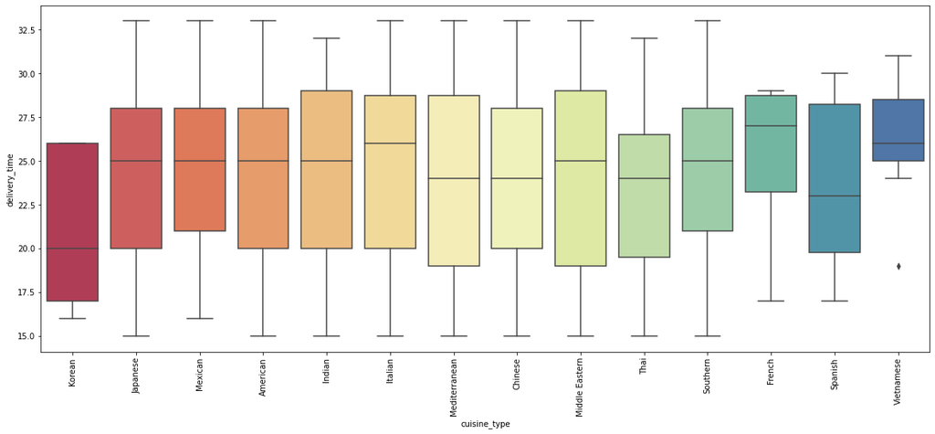

```python
#Relationship between Cuisine Type and Delivery Time
plt.figure(figsize=(20,8))
sns.boxplot(data=df,x = "cuisine_type", y = "delivery_time", palette = 'Spectral')
plt.xticks(rotation = 90)
plt.show()
```

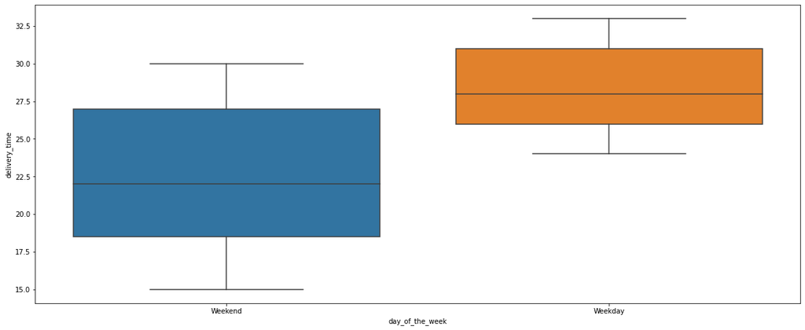

```python
# Relationship between Day of the week and Delivery time
plt.figure(figsize=(20,8))
sns.boxplot(data=df,x='day_of_the_week',y="delivery_time")
plt.show()
```

The median delivery time is faster on the weekends versus on the weekdays. Median week day delivery time - 28 minutes. Median Weekend delivery time - 22 minutes.

```python
df.groupby(['restaurant_name'])['cost_of_the_order'].sum().sort_values(ascending = False).head(10) #Displays the top ten restaurants who have earned the most revenue in the dataset
```

```
restaurant_name
Shake Shack                      3579.53
The Meatball Shop                2145.21
Blue Ribbon Sushi                1903.95
Blue Ribbon Fried Chicken        1662.29
Parm                             1112.76
RedFarm Broadway                  965.13
RedFarm Hudson                    921.21
TAO                               834.50
Han Dynasty                       755.29
Blue Ribbon Sushi Bar & Grill     666.62
Name: cost_of_the_order, dtype: float64
```

Observation: Shake Shack has earned the most revenue out of all the restuarants in the data set.

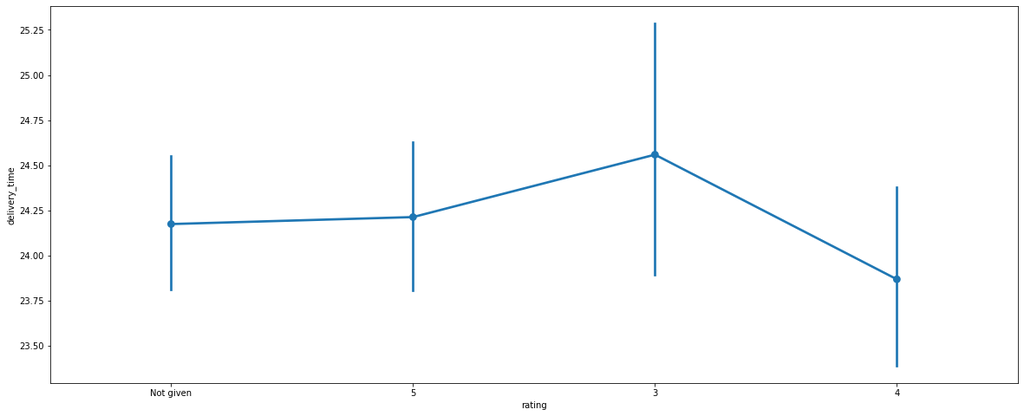

```python
# Rating and Delivery Time - Relationship
plt.figure(figsize=(20, 8))
sns.pointplot(data=df,x = 'rating', y = 'delivery_time')
plt.show()
```

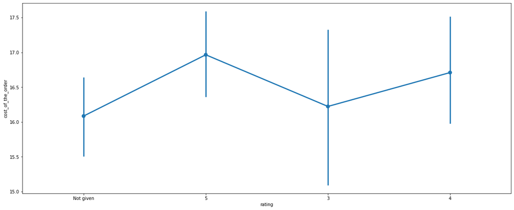

```python
# Relationship between Rating and Cost of the order
plt.figure(figsize=(20, 8))
sns.pointplot(data=df,x='rating',y='cost_of_the_order')
plt.show()
```

### Observations- According to the findings in the graph, higher rating is associated with higher cost of the order. The quality of the food may lead to higher prices and a higher satisfaction rating.

### **Question 13:** The company wants to provide a promotional offer in the advertisement of the restaurants. The condition to get the offer is that the restaurants must have a rating count of more than 50 and the average rating should be greater than 4. Find the restaurants fulfilling the criteria to get the promotional offer. [3 marks]

```python
# Filters the restaurants that are rated
df_rate = df[df['rating'] != 'Not given'].copy()

# The rating column is converted from object type to integer type
df_rate['rating'] = df_rate['rating'].astype('int')

# Create a dataframe that has the restuarant names associated with the rating counts
df_rating_count = df_rate.groupby(['restaurant_name'])['rating'].count().sort_values(ascending = False).reset_index()
df_rating_count.head()
```

|  | restaurant_name | rating |
| --- | --- | --- |
| 0 | Shake Shack | 133 |
| 1 | The Meatball Shop | 84 |
| 2 | Blue Ribbon Sushi | 73 |
| 3 | Blue Ribbon Fried Chicken | 64 |
| 4 | RedFarm Broadway | 41 |

```python
# Retrieve the restaurant names that have rating count more than 50
rest_names = df_rating_count.loc[df_rating_count['rating']>50]['restaurant_name']
print(rest_names)
```

```
0                  Shake Shack
1            The Meatball Shop
2            Blue Ribbon Sushi
3    Blue Ribbon Fried Chicken
Name: restaurant_name, dtype: object
```

```python
# Restuarants that have a rating count of more than 50 are filtered
df_mean_4 = df_rate[df_rate['restaurant_name'].isin(rest_names)]
# Group the restaurant names with their ratings and discover the mean rating of each restaurant
df_mean_4.groupby(['restaurant_name'])['rating'].mean().sort_values(ascending = False).reset_index()
```

|  | restaurant_name | rating |
| --- | --- | --- |
| 0 | The Meatball Shop | 4.511905 |
| 1 | Blue Ribbon Fried Chicken | 4.328125 |
| 2 | Shake Shack | 4.278195 |
| 3 | Blue Ribbon Sushi | 4.219178 |

#### Observations: The Meatball Shop, Blue Ribbon Fried Chicken, Shake Shack, and Blue Ribbon Sushi have a rating count of more than 50 and an average rating of at least 4.

### **Question 14:** The company charges the restaurant 25% on the orders having cost greater than 20 dollars and 15% on the orders having cost greater than 5 dollars. Find the net revenue generated by the company across all orders. [3 marks]

```python
def rev(z):
  if z > 20:      #creates a condition where cost is greater than 20 dollars
    return z*0.25 #returns 25% revenue of the orders
  if z>5:         #creates a condition where cost is greater than 5 dollars
    return z*0.15 #returns 15% revenue of the orders
  else:
    return z*0    #returns 0% revenue of the orders

df['Revenue'] = df['cost_of_the_order'].apply(rev) #revenue function is applied to the cost of the order column
df['Revenue']
```

```
0       7.6875
1       1.8120
2       1.8345
3       7.3000
4       1.7385
         ...
1893    5.5775
1894    1.8270
1895    6.3050
1896    1.8270
1897    2.9175
Name: Revenue, Length: 1898, dtype: float64
```

```python
#Print the total revenue
total_rev = df['Revenue'].sum() #calculates the sum of the 'Revenue' column
print('The total revenue is around', round(total_rev,2),'dollars)') #prints the revenue
```

```
The total revenue is around 6166.3 dollars)
```

#### Observations: The total revenue is around 6166.3 dollars.

### **Question 15:** The company wants to analyze the total time required to deliver the food. What percentage of orders take more than 60 minutes to get delivered from the time the order is placed? (The food has to be prepared and then delivered.) [2 marks]

```python
df['total_time']= df['food_preparation_time']+df['delivery_time'] #adds a new column 'total time' to the dataframe, combining the food prep time and delivery time = Total time
greaterthan60=df[df['total_time']>60] #creates a new dataframe filtering the orders that take more than 60 min to get delivered
Percent = (greaterthan60.shape[0]/df.shape[0])*100 #calculates the percentage of orders that take more than 60 min to prep and deliver
Percent
```

```
10.537407797681771
```

### **Question 16:** The company wants to analyze the delivery time of the orders on weekdays and weekends. How does the mean delivery time vary during weekdays and weekends? [2 marks]

```python
##mean delivery time on weekdays and print it
print('The mean delivery time on weekdays is around',
      round(df[df['day_of_the_week'] == 'Weekday']['delivery_time'].mean()),
     'minutes')
                ##creates a new data frame filtering for the weekday and calculates the average delivery time of the specific data frame

#Mean delivery time on weekends and print it
print('The mean delivery time on weekends is around',
      round(df[df['day_of_the_week'] == 'Weekend']['delivery_time'].mean()),
     'minutes') ##creates a new data frame filtering for the weekend and calculates the average delivery time of the specific data frame
```

```
The mean delivery time on weekdays is around 28 minutes
The mean delivery time on weekends is around 22 minutes
```

#### Observations: The mean delivery time on weekends is around 22 minutes, whereas the mean delivery on weekdays is around 28 minutes. Average weekend delivery time is 6 minutes shorter than week day delivery time. Food Hub can recommend the delivery drivers to become more efficient during the week days to match the weekend delivery time.

### Conclusion and Recommendations

### **Question 17:** What are your conclusions from the analysis? What recommendations would you like to share to help improve the business? (You can use cuisine type and feedback ratings to drive your business recommendations.) [6 marks]

### Conclusions:

*'day_of_the_week', "cuisine_type", "food_preparation_time", "restuarant_name", "rating", "delivery time", and "cost_of_the_order" were the important variables to analyze in the data set.

In terms of univariate analysis, American food is the most popular cuisine type and double amount of the orders occur on the weekend as compared to the weekday. Shakeshack, Blue Ribbon Sushi, and the Meatball shop are the most popular restaurants. The median delivery time is 25 minutes. The median food preparation time is 27 min. Most orders were not rated but the ones that were rated received a 5 rating majority of the orders

### Recommendations:

- Recommendations for Food Hub would be to advertise (digital marketing) for American food since it is the most popular cuisine type among the customers. Potentially adding American food to the top of the web page can lead to a higher conversion rate. Not only is American food popular, but also Japanese and Italian Food are very popular as well (advertising those cuisine types would benefit the company). Since the Meatball Shop, Blue Ribbon Fried Chicken, Shake Shake, and Blue Ribbon Sushi had a rating count of more than 50 and an average rating of at least 4, Food Hub should increase the advertising spent on these restuarants to attract more customers and therefore create a higher ROAS - return on ads spent. In regards to the higher delivery time on the week days (as compared to the weekends), Food Hub can hire more drivers or create a more efficient delivery process to match the delivery time on the weekends. In conclusion, advertising the restuarants that are popular and that have high rating will produce more revenue for Food Hub.